# LAFinal

Jaime Vargas

12/7/2019

# A

First we read the image from the csv

```r
imageData = read.csv("C:/Users/lalin/Desktop/imageSVD.csv", header = FALSE)
```

Then we will perform an SVD model on the image

```r
svdImage = svd(imageData)
```

We want to find the total variance which are the eigenvalues added, which is the concepts squared.

```r
eigenvalues = svdImage$d^2
```

To maintain 90% of the variance, we need to see how much each component covers using the Eigenvalues

```r
varFraction = eigenvalues/sum(eigenvalues)
number = 0
for (fraction in cumsum(varFraction)){
  number <- number + 1
  if (fraction >= 0.9){
    break
  }
}
number
```

```
## [1] 18
```

We get the variance represented by each eigenvalue and add them in a loop until we pass 90%. We add the number of loops to get the number.

Looks like k = 18.

# B

Here we plot the cummulative varaince.

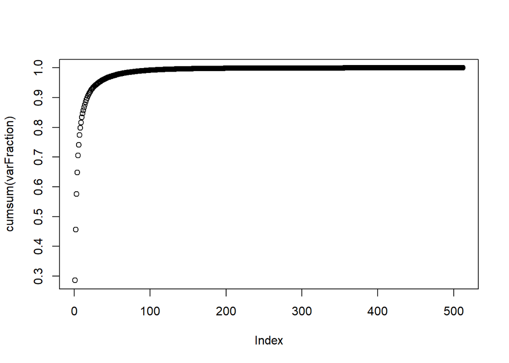

```r
plot(cumsum(varFraction))
```

Since `varfraction` stores our individual variance, I used the cumsum function to add the variances each time

# C

I will compress the image by only getting the first 18 columns of U, the first 18 diagonals of sigma and the first 18 rows of v transposed, cutting out the useless noise.

Then I will examine the matrix at certain points,

```r
compressedImage = svdImage$u[,1:18]%*%diag(svdImage$d[1:18])%*%t(svdImage$v)[1:18,]

compressedImage[1,1]
```

```
## [1] 15.27248
```

```r
compressedImage[256,256]
```

```
## [1] -10.25841
```

```r
compressedImage[512, 512]
```

```
## [1] -53.56488
```

# D

The error from the compression.

```r
library(pracma)

norm(imageData - compressedImage, '2')
```

```
## [1] 1788.913
```

it seems like the error is 1788.9.

# E

## Display the orinal image

First we will display the original image with an added mean of 123.55

[figure not shown]

```r
imageCentered = apply(imageData, c(1,2), function(x) x + 123.55)
image(imageCentered)
```

Looks off, but techincally it’s the image…

## Display the compressed image

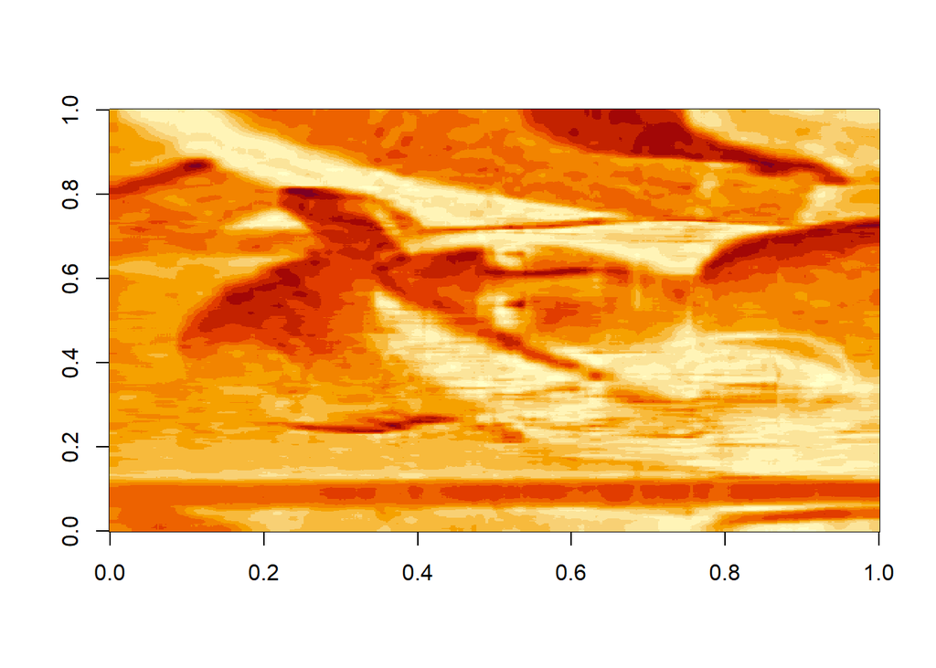

```r
imageCenteredComp = apply(compressedImage, c(1,2), function(x) x + 123.55)
image(imageCenteredComp)
```

Certainly looks blurrier.